# Super ResLight

Para problemas de **Restauração/Melhoramento/Geração de Imagens**: Modelos de Super Resolução e Aprimoramento de Baixa Luminosidade

**Integrantes:** Rafael Fernandes

## Super Resolution e Low Light Enhancement

Problemas de resolução:

[figure not shown]

0.5x

[figure not shown]

4.0x

[figure not shown]

1x

## Super Resolution e Low Light Enhancement

Problemas de luminosidade:

[figure not shown]

Baixa Luz

[figure not shown]

Alta Luz

### 3 Métodos de Melhoramento

**Histograma** → Rearranjam pixels uniformemente  
**Teoria Retinex** → Reflectância + Brilho  
**Deep Learning** → Redes Neurais Profundas

### Deep Learning: Como Funciona?

**Treinamento**

- Imagens com **qualidades diferentes**
- Imagem de **alta qualidade** = ground truth
- Objetivo: aproximar do ground truth

**Avaliação**  
**Por Pixel**: MSE,PSNR  
**Por Percepção**: LPIPS (percepção humana)

**Referência:** M. Rasheed, D. Shi - LSR: Lightening super-resolution deep network

### Aplicações

Essas técnicas têm **aplicações abrangentes** para a resolução de problemas reais, alguns exemplos são:

- Detalhamento de imagens como **pré-processamento** para modelos de Machine Learning, a fim de **aumentar o desempenho**;
- Melhoramento de imagens de **câmeras de segurança** ou **policiais**, a fim de **facilitar julgamentos** ou **identificação de suspeitos**;
- Reconstrução de **imagens antigas** ou de **câmeras mais limitadas**;
- Qualquer outro uso que se beneficia de uma **imagem melhor e mais limpa**.

## O Dataset: RELLISUR (Real Low-Light Image Super-Resolution)

**Paper**: Andreas Aakerberg, Kamal Nasrollahi, and Thomas B. Moeslund. “RELLISUR: A Real Low-Light Image Super-Resolution Dataset.” Version 1.0.0. Zenodo, August 23, 2021. https://doi.org/10.5281/ZENODO.5234969.

- Objetivo: integrar problemas de melhoramento de imagem por Super Resolution, ou por Low Light Enhancement.
- Não geram imagens de baixa resolução e luminosidade digitalmente, mas fazem as diferenciações já na captura das imagens
  - **Resolução**: diferentes valores de zoom, alterando lentes com diferentes distâncias focais;
  - **Iliminação**: diferentes valores de exposição;

### Resolução

As imagens de para Super Resolution são divididas em 3 tipos:

(menor qualidade) **1x -> 2x -> 4x** (maior qualidade)

[figure not shown]

Diferentes resoluções: retirada diretamente do paper

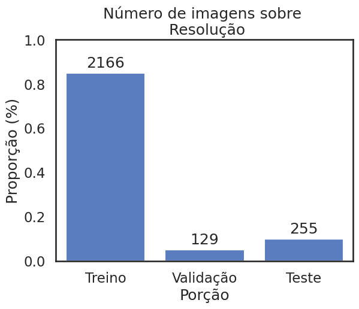

### Baixa Luminosidade

As imagens para Low Light Enhancement são divididas em 5 tipos:

(Mais clara) **2.5 -> 3.0 -> 3.5 -> 4.0 -> 4.5** (Mais escura)

[figure not shown]

Diferentes iluminações: retiradas diretamente do paper

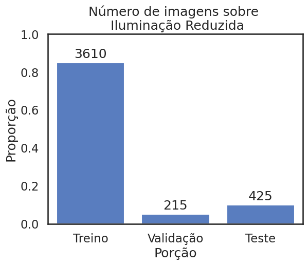

## Utilização do Dataset

**Objetivo**:  
Preencher lacuna de **melhoramento completo**: Resolução + Iluminação em **treinamento end-to-end**

### Estrutura do Dataset

**Manipulações aplicadas:**

- Resolução: 1x, 2x, 4x
- Iluminação

**Resultado:** 12.750 pares de imagens

### Aplicações

**3 modos de uso:**

1. Super Resolution isolado
2. Low Light Enhancement isolado
3. Ambos combinados

### Licença

**CC BY 4.0** - Uso livre desde que creditados os autores e mudanças indicadas

## Características dos Dados

### Iluminação

Todas as imagens: **625x625 pixels** (1x)  
**Problema:** Imagens escuras demais podem dificultar validação visual (ex: pássaros, artefatos)

### Resolução

- **1x** = 625 x 625
- **2x** = 1250 x 1250
- **4x** = 2500 x 2500

**Problemas:**

- Capturas rápidas podem ter pequenas diferenças entre frames
- Recortes podem ser irregulares (apesar de SURF features + MSAC)

### Contexto das Imagens

**Distribuição balanceada:**

- Ambiente externo: ~51%
- Ambiente interno: ~49%

**→ Evita modelo enviesado**

### Privacidade

**Dataset sem informações identificáveis:**

- Sem pessoas/rostos
- Sem placas de carro
- Sem conteúdo ofensivo

**Limitação:** Modelo pode performar pior em imagens com essas características/

## Planejamento Inicial

### Pré-Processamento

**Data Augmentation:**

- Rotação e translação de imagens
- Aplicar mesmas transformações às imagens ground-truth

**Vantagem do dataset:** Não possui desbalanceamento ou problemas comuns pela natureza do problema

### Experimentos Iniciais

**Objetivo:** Começar pelo mais simples para validar método de treinamento

**Arquitetura:**

- CNNs convencionais
- Otimizador: ADAM

**Loss Functions:**

- MSE ou PSNR

**Estratégia:**

- Separar problemas: treinar modelos isolados
  - Super Resolution apenas
  - Low Light Enhancement apenas

**Expectativa:** Resultados modestos, mas suficientes para validação do método

### Próximos Passos

- **Testar outras arquiteturas de redes**: U-Net, Res-Net, Redes Adversárias;
- **Testar outras losses**: procurar outras métricas por píxel, e também por percepção;
- **Juntar o problema**: treinamento end-to-end;

## Referências

**Paper do dataset**: Andreas Aakerberg, Kamal Nasrollahi, and Thomas B. Moeslund. “RELLISUR: A Real Low-Light Image Super-Resolution Dataset.” Version 1.0.0. Zenodo, August 23, 2021. https://doi.org/10.5281/ZENODO.5234969.

(**M. Rasheed, D. Shi,LSR**: *Lightening super-resolution deep network for low-light image enhancement*): https://www.sciencedirect.com/science/article/abs/pii/S092523122200916X

**Super-resolution Neural Networks (Amit Yadav)**: https://medium.com/@amit25173/super-resolution-neural-networks-3f27b64ad6f8